# Heterogeneous Treatment Effects

CML Week 5

2026-09-29

## Schedule

1. Design-based causal inference & Monte Carlo simulation
2. Covariate adjustment
3. Balancing weights
4. Double robustness, Double ML and TMLE
5. **Heterogeneous Treatment Effects**
6. HTE II: Neural Networks
7. Off-policy evaluation and optimization
8. Experimental design
9. Panel data and the new diff-in-diff
10. Partial Identification
11. Response adaptation
12. Interference

## Thus far

- Every week so far has targeted one number: the **average treatment effect** $\tau = E[Y(1) - Y(0)]$
- Design-based inference: randomisation identifies it without a model
- Covariate adjustment, balancing weights, double robustness: three routes to a *better estimate of the same average*

**But what if treatment effects vary?**

- *Medical treatments*: some patients benefit, others don’t (or are harmed)
- *Policy interventions*: context matters for effectiveness
- *Marketing*: not all customers respond the same way

**Goal today:** understand why estimating heterogeneous effects is fundamentally harder than it seems, and where the ideas for doing it better come from.

# (Holland 1986)

## The Fundamental Problem of Causal Inference

> For any individual unit $i$, we can never observe both $Y_i(1)$ and $Y_i(0)$ simultaneously.
- Each unit has two potential outcomes: $Y_i(1)$ and $Y_i(0)$
- We only observe: $Y_i = A_i Y_i(1) + (1-A_i) Y_i(0)$
- The individual treatment effect $\tau_i = Y_i(1) - Y_i(0)$ is fundamentally unobservable

**Why it’s fundamental:**

- Not a sample size problem (more data doesn’t help)
- Not a measurement problem (we can’t measure what doesn’t exist in our world)
- It’s a metaphysical constraint on what we can learn from data

**Implications:**

- We can make causal claims about populations or subgroups
- We cannot make causal claims about specific individuals with certainty
- All individual-level causal predictions are inherently model-dependent

## What can we learn about individuals?

**What we cannot identify:**

- Individual treatment effect: $\tau_i = Y_i(1) - Y_i(0)$
- Whether a specific person benefited from treatment

**What we can identify (under assumptions):**

- Average Treatment Effect: $\tau = E[Y(1) - Y(0)]$
- Conditional Average Treatment Effect: $\tau(x) = E[Y(1) - Y(0) \mid X = x]$

**CATE as a compromise:**

$$\tau(x) = E[Y(1) - Y(0) \mid X = x]$$

- Not about individuals, but about groups defined by $X$
- As $X$ becomes more detailed, groups become smaller
- But we still need multiple units with similar $X$ to estimate $\tau(x)$
- Bias-variance tradeoff: more granular $X$ means smaller groups, higher variance

## The role of randomization

**For the ATE, randomization is powerful:**

- Ensures $A \perp (Y(1), Y(0))$
- Simple difference in means is unbiased: $E[\bar{Y}_{A=1} - \bar{Y}_{A=0}] = \tau$
- No modeling assumptions needed

**For HTEs, randomization helps less:**

- Still have $A \perp (Y(1), Y(0)) \mid X$
- But now we need sufficient treated and control units at each value of $X$
- As the dimension of $X$ grows, randomization provides less “insurance”
- We’re back to needing models to extrapolate across covariate space

**The curse of dimensionality:**

- With 10 binary covariates: $2^{10} = 1024$ subgroups
- Even in a large RCT, many subgroups may have no treated or control units
- Must borrow strength across subgroups (i.e., model)

## How can we do machine learning?

**The standard supervised learning paradigm:**

1. Observe many examples of $(X_i, Y_i)$
2. Learn function $f: X \to Y$ that minimizes prediction error
3. Validate on held-out test set
4. If test error is low, we trust the model

**The temptation:**

- Input: covariates $X$
- Output: treatment effect $\tau(x)$
- Just use your favorite ML algorithm on observed $(X_i, A_i, Y_i)$!

**Why this fails for HTE:**

- No observed target: we never see $\tau_i = Y_i(1) - Y_i(0)$
- No natural loss function: can’t compute $(\hat{\tau}(X_i) - \tau_i)^2$ to optimize
- Validation is impossible: can’t check if predictions are good on a test set

## The problem with naive approaches

Consider the naive “difference in predictions” approach (**T-learner**):

1. Train $\hat{\mu}_1(x)$ to predict $Y$ among treated units
2. Train $\hat{\mu}_0(x)$ to predict $Y$ among control units
3. Estimate $\hat{\tau}(x) = \hat{\mu}_1(x) - \hat{\mu}_0(x)$

(**S-learner**: train $\hat{\mu}(a, x)$ by predicting $Y$ with $(A, X)$ on all data)

This conflates two distinct concepts:

- Prognostic variables: $X$ predicts $Y$ regardless of treatment (baseline risk)
- Effect moderators: $X$ modifies the treatment effect

**The consequence:** overfitting to noise in the heterogeneity, mistaking prognostic variables for moderators, and overconfident, miscalibrated predictions.

**What we need:** methods that explicitly target $\tau(x)$, not just $Y$

# Bonus: (Leng and Dimmery 2024)

## What can we observe about our HTE estimates?

You ran an RCT, used a sophisticated HTE method and have $\hat{\tau}(X_i)$ for all units. **Are these estimates trustworthy?**

**Observation:** we *can* observe subgroup average effects. For any subgroup $S$, the difference in means is unbiased for $E[\tau \mid X \in S]$. So build the subgroups from $\hat{\tau}(X_i)$ itself and check whether they deliver what they promise.

**Calibration check:**

1. Sort units by $\hat{\tau}(X_i)$ into quantiles (e.g., deciles)
2. In each quantile $q$, compare the predicted effect $\bar{\hat{\tau}}_q = \frac{1}{n_q}\sum_{i \in q} \hat{\tau}(X_i)$ with the observed one $\bar{\tau}_q = \bar{Y}_{A=1,q} - \bar{Y}_{A=0,q}$
3. Plot predicted vs. observed

**Perfect calibration:** points lie on the 45-degree line

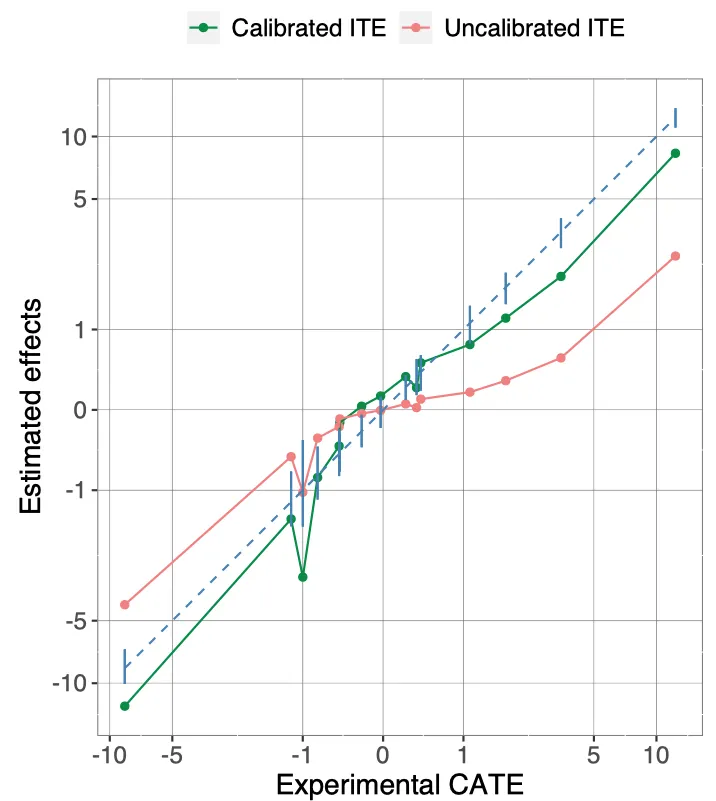

## Calibration in practice

**Evidence from large-scale experiments** (Facebook, Criteo platforms):

- Substantial miscalibration: ML-based HTE estimates are often poorly calibrated
- Range compression: predicted effects are tightly clustered, observed effects are much wider

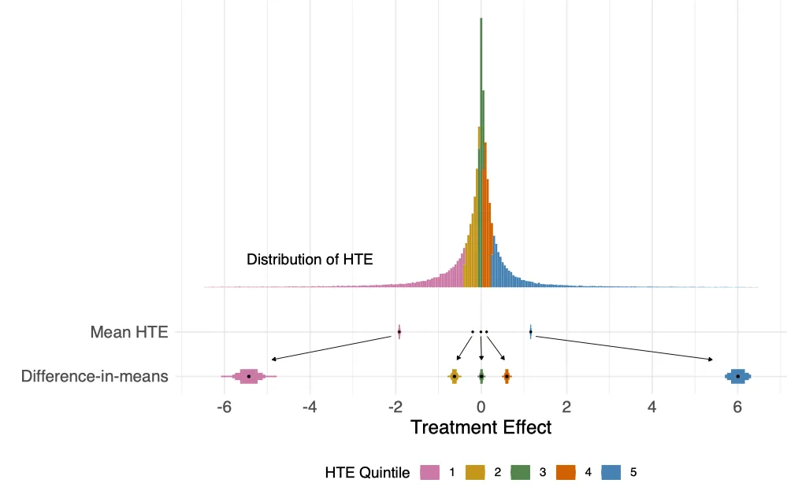

**Why does this happen?**

- Optimization targets prediction of $Y$, not $\tau$
- Small treatment effects relative to outcome variance
- Prognostic/predictive confusion amplified by complex models

## Bonus: (Arbour, Dimmery, and Rao 2021)

**A complementary approach:** can we do better if we *choose* how to assign treatment?

- Not all units are equally informative about $\tau(x)$
  - Units with common covariate values: less valuable (we already have many like them)
  - Units with rare covariate values: more valuable (fill in gaps in covariate space)

**Locally balanced assignments:**

- Ensure good balance not just on average, but locally
- Assignments are well distributed across covariate space

**Connection to today’s themes:**

- Design can’t solve the Fundamental Problem
- But it can make sure you don’t shoot yourself in the foot

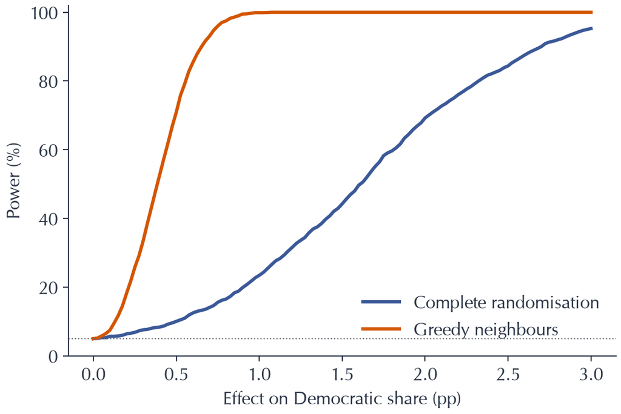

## Takeaways

- **The Fundamental Problem matters:**
  - We can never observe individual treatment effects
  - This makes HTE estimation fundamentally different from supervised learning
  - Standard ML intuitions can mislead us
- **What makes HTE hard:**
  - No ground truth for validation
  - Easy to overfit to noise
  - Prognostic vs. predictive confusion
- **Practical implications:**
  - Need specialized methods (which students will present today)
  - Need calibration checks when possible
  - Skepticism is warranted for HTE claims

## Open questions

1. **Adapting a workhorse:** Random forests predict $Y$ well. Can a forest target $\tau(x)$ directly, and still deliver valid confidence intervals?
   - *Motivates:* (Wager and Athey 2018) on causal forests
2. **Combining models:** If we already have good outcome models, how should we combine them to get $\tau(x)$, and when does each recipe win?
   - *Motivates:* (Künzel et al. 2019) on meta-learners
3. **Double robustness for CATEs:** Last week’s machinery hedged between two models for one number. Can it be pointed at $\tau(x)$, and how fast can we learn it?
   - *Motivates:* (Kennedy 2020) on the DR-learner
4. **Inference without a target:** If $\tau_i$ is never observed, what *can* we test about heterogeneity in an RCT with honest inference?
   - *Motivates:* (Chernozhukov et al. 2025) on generic ML inference

## More to read

| Paper | Why you’d read it |
| --- | --- |
| (Athey and Imbens 2019) | The review that frames today: the ML toolkit for applied economists, and where its causal uses part ways with prediction. |
| (Wager and Athey 2018) | Causal forests: *honest* trees (split on one half, estimate on the other) give consistency and asymptotic normality for $\tau(x)$. |
| (Künzel et al. 2019) | Meta-learners: S-, T- and X-learners as recipes for any base learner. The X-learner wins when the arms are unbalanced. |
| (Kennedy 2020) | The DR-learner: regress a doubly robust pseudo-outcome on $X$. The error is a product of nuisance errors, as last week. |
| (Chernozhukov et al. 2025) | Generic ML: test for heterogeneity (BLP), sort groups by it (GATES), describe them (CLAN), with valid inference after sample splitting. |
| (Athey and Imbens 2016); (Athey, Tibshirani, and Wager 2019) | The honest causal tree before causal forests, and the general framework (forests for any local moment condition) after. |
| (Nie and Wager 2021) | The R-learner: Robinson’s residual-on-residual regression as a loss for $\tau(x)$, with quasi-oracle rates. |

# Deeper dive: (Kennedy 2020)

## The DR-learner

1. **Nuisance training:** the propensity score $\hat{e}$ (in an RCT, known) and the regression functions $\hat{\mu}_1, \hat{\mu}_0$
2. **Pseudo-outcome:** an unbiased estimate of each unit’s treatment effect
   $$\hat{\varphi} = \frac{A - \hat{e}}{\hat{e}\,(1 - \hat{e})}\,\big(Y - \hat{\mu}_A\big) + \hat{\mu}_1 - \hat{\mu}_0$$
3. **Smooth the pseudo-outcome:** regress $\hat{\varphi}$ on $X$ with any ML method. The fit is $\hat{\tau}_{dr}(x)$.
- Nuisance training and smoothing must be on separate subsamples (cross-fitting); rotate the folds and average.

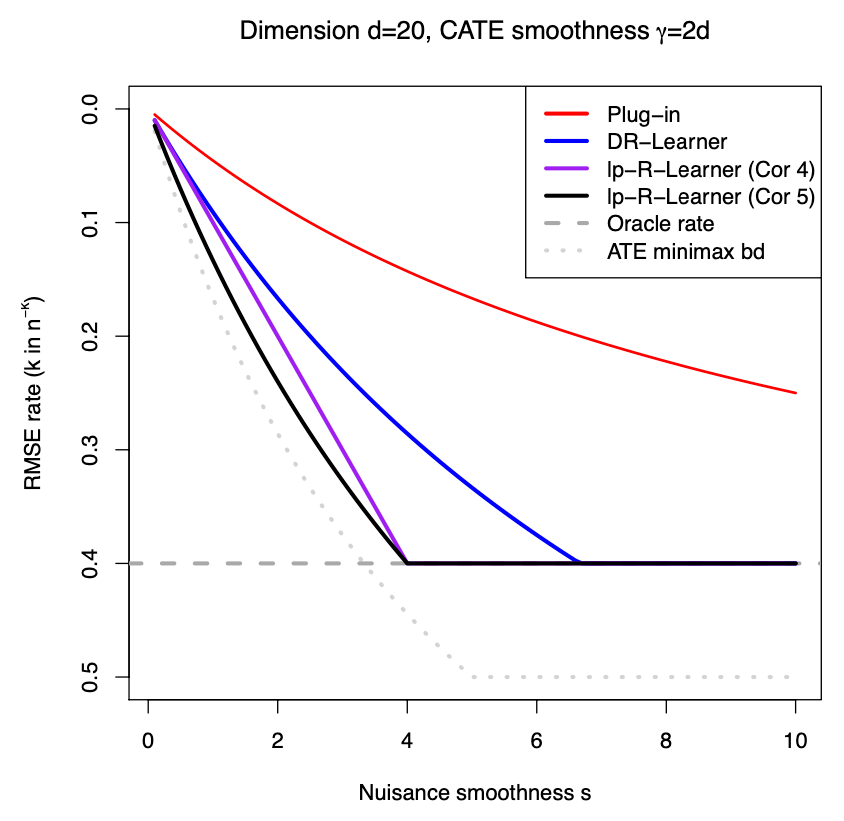

## Why does this work?

- $\varphi$ is the uncentred efficient influence function of the ATE: AIPW, pointwise
- Its conditional mean is the CATE: $E[\varphi \mid X] = \tau(X)$. Smoothing $\varphi$ over $X$ is a regression with the right target.
- Plugging in $\hat{e}, \hat{\mu}_a$ adds bias only through the product of their errors: doubly robust at every $x$.

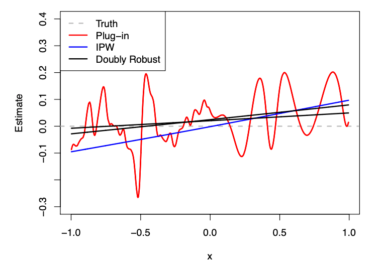

Kennedy’s simulation: rough $\mu_a$, flat $\tau$. Only the plug-in inherits the roughness.

- Error $=$ *oracle* error of regressing the true $\varphi$ on $X$, plus $\hat{b}(x)^2$
- Harder than the ATE by a factor growing in $\dim X$, shrinking in $\tau$’s smoothness

$$\hat{b}(x) = E[\hat{\varphi} - \varphi \mid X = x] = (e - \hat{e})\left\{\frac{\mu_1 - \hat{\mu}_1}{\hat{e}} + \frac{\mu_0 - \hat{\mu}_0}{1 - \hat{e}}\right\}$$

## Why does it work better than the X-learner?

- The X-learner doesn’t benefit from convergence in the propensity score
- In these experiments we *know* the true propensity score!
- We’re using our outcome models as a control variate to reduce variance
  - For a stratified second-stage model, *this is just AIPW*
- **In practice:** pseudo-outcomes are noisy (they divide by $\hat{e}(1 - \hat{e})$), so clip $\hat{e}$ and regularise the second stage. In an RCT with known $e$, $\hat{b}(x) = 0$ however bad the $\hat{\mu}_a$ are.

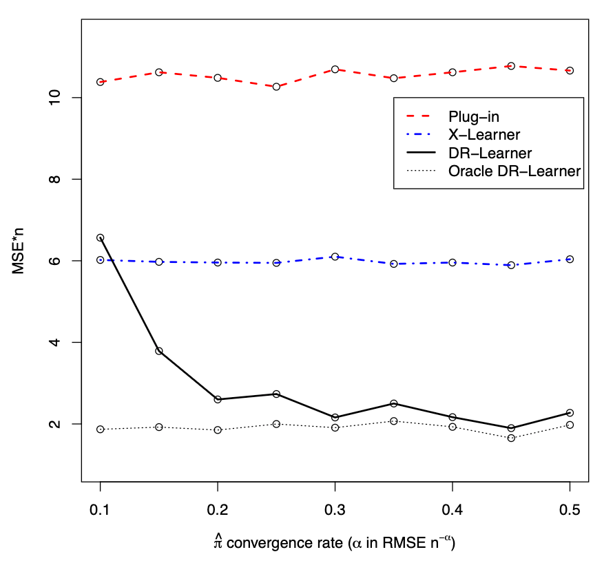

# References

Arbour, David, Drew Dimmery, and Anup Rao. 2021. “Efficient Balanced Treatment Assignments for Experimentation.” In *Proceedings of the 24th International Conference on Artificial Intelligence and Statistics*, edited by Arindam Banerjee and Kenji Fukumizu, 130:3070–78. Proceedings of Machine Learning Research. PMLR. https://proceedings.mlr.press/v130/arbour21a.html.

Athey, Susan, and Guido Imbens. 2016. “Recursive Partitioning for Heterogeneous Causal Effects.” *Proceedings of the National Academy of Sciences* 113 (27): 7353–60.

Athey, Susan, and Guido W Imbens. 2019. “Machine Learning Methods That Economists Should Know About.” *Annual Review of Economics* 11: 685–725.

Athey, Susan, Julie Tibshirani, and Stefan Wager. 2019. “Generalized Random Forests.” *Annals of Statistics* 47 (2): 1148–78.

Chernozhukov, Victor, Mert Demirer, Esther Duflo, and Iván Fernández-Val. 2025. “Fisher–Schultz Lecture: Generic Machine Learning Inference on Heterogeneous Treatment Effects in Randomized Experiments, with an Application to Immunization in India.” *Econometrica* 93 (4): 1121–64.

Holland, Paul W. 1986. “Statistics and Causal Inference.” *Journal of the American Statistical Association* 81 (396): 945–60.

Kennedy, Edward H. 2020. “Towards Optimal Doubly Robust Estimation of Heterogeneous Causal Effects.” *arXiv Preprint arXiv:2004.14497*.

Künzel, Sören R, Jasjeet S Sekhon, Peter J Bickel, and Bin Yu. 2019. “Metalearners for Estimating Heterogeneous Treatment Effects Using Machine Learning.” *Proceedings of the National Academy of Sciences* 116 (10): 4156–65.

Leng, Yan, and Drew Dimmery. 2024. “Calibration of Heterogeneous Treatment Effects in Randomized Experiments.” *Information Systems Research* 35 (4): 1721–42.

Nie, Xinkun, and Stefan Wager. 2021. “Quasi-Oracle Estimation of Heterogeneous Treatment Effects.” *Biometrika* 108 (2): 299–319.

Wager, Stefan, and Susan Athey. 2018. “Estimation and Inference of Heterogeneous Treatment Effects Using Random Forests.” *Journal of the American Statistical Association* 113 (523): 1228–42.